# GitHub

Project: In this example, I demonstrate usage of functions stored in my GitHub.

Notes: For my various projects, I like to keep styles and color schemes consistent, to enhance the presentation of results accross various projects and ensure graphs are readable. I also re-use code for cleaning quanitative or text data. Storing this type of re-usable code on GitHub and calling it into future analysis scripts is an efficient way to re-use code, save time, and achieve consistency accross projects.

Data: This demo uses randomly generated data.

Please note that this notebook contains only a small example for demonstartion purposes. The purpose of this notebook is to demonstrate the thought process and is not exhaustive or complete.

## Load packages

```python
# with pip
!pip install rise

# or install with conda
!conda install -c conda-forge rise
```

## Example 1: usage of custom text cleaning script with GitHub script

```python
#### GitHub script for text cleaning (NLP pre-processing step)

### This is a demonstration of calling the cleaning script and checking that it works properly

## Load the GitHub importing package
import requests

## Import the script and check it works

# URL to the raw script file on GitHub
url = "https://raw.githubusercontent.com/MiThomato/JuDIS/main/TextCleaner.py"

# Fetch the script from GitHub
response = requests.get(url)

# Check if the request was successful
if response.status_code == 200:
    script_content = response.text
    print("Success, your script imports and runs just fine!")
    # Execute the script
    exec(script_content)
else:
    print(f"Failed to fetch script: {response.status_code}")
```

## Example 2: usage of custom colors for graphs with GitHub scripts

A: one for patapoints (dp) B: one for bar graphs (bars)

### A: Example usage of custom colors for overlaying individual datapoints

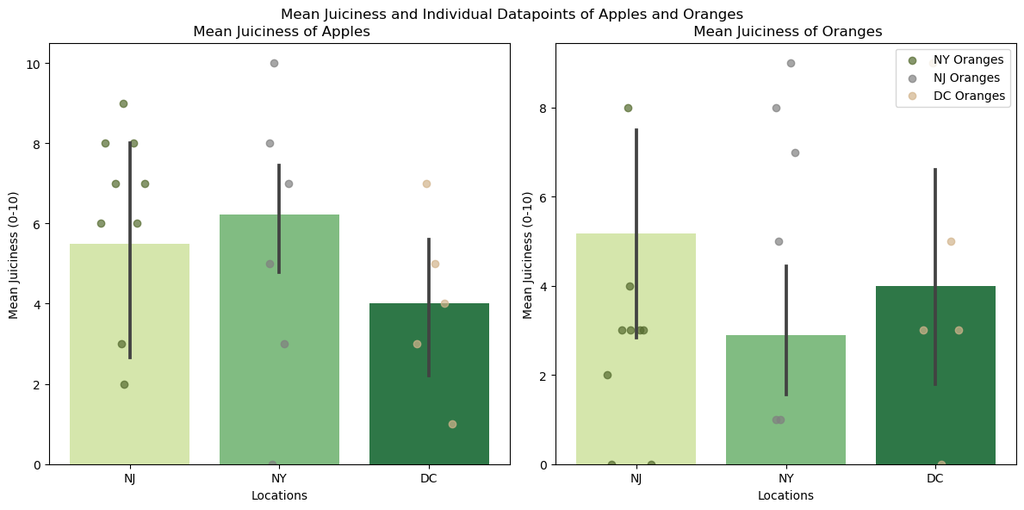

```python
#### Example usage of custom colors for overlaying individual datapoints:

### This script does not load the libraries as it is used to call a color palette into a script
### This example plots a figure with random data and uses dp_cols_green_tan to
### overlay visible and color-coordinated individual datapoints on top of YlGn bars

### Libraries
import matplotlib.pyplot as plt
import seaborn as sns
import numpy as np
import requests

### Part A.

## Step 0: Download the script from GitHub
url = 'https://raw.githubusercontent.com/MiThomato/Graphs/main/dp_cols_green_tan.py'
response = requests.get(url)
exec(response.text)

colors = get_dp_cols_green_tan()

### Part B.

## Step 2: Generate example data
np.random.seed(0)
n_points = 20
apples_mean_juiciness = np.random.randint(0, 11, size=n_points)
oranges_mean_juiciness = np.random.randint(0, 11, size=n_points)
locations = ['NY', 'NJ', 'DC']
locations_data = np.random.choice(locations, size=n_points)

## Step 3: Create bar plots
fig, axs = plt.subplots(1, 2, figsize=(12, 6))

# Bar plot for apples
sns.barplot(x=locations_data, y=apples_mean_juiciness, palette=sns.color_palette('YlGn', 3), ax=axs[0])
axs[0].set_title(' \n Mean Juiciness of Apples')
axs[0].set_xlabel('Locations')
axs[0].set_ylabel('Mean Juiciness (0-10)')

# Bar plot for oranges
sns.barplot(x=locations_data, y=oranges_mean_juiciness, palette=sns.color_palette('YlGn', 3), ax=axs[1])
axs[1].set_title(' \n Mean Juiciness of Oranges')
axs[1].set_xlabel('Locations')
axs[1].set_ylabel('Mean Juiciness (0-10)')

## Step 4: Add individual datapoints with jitter
for i, loc in enumerate(locations):
    # Jitter x positions for better visualization
    x_jitter = np.random.normal(i, 0.1, size=n_points)

    # Scatter plot for apples
    axs[0].scatter(x_jitter[locations_data == loc], apples_mean_juiciness[locations_data == loc],
                   color=colors[i], label=f'{loc} Apples', alpha=0.7)

    # Scatter plot for oranges
    axs[1].scatter(x_jitter[locations_data == loc], oranges_mean_juiciness[locations_data == loc],
                   color=colors[i], label=f'{loc} Oranges', alpha=0.7)

## Step 5: Finalize and show the plot
fig.tight_layout()
plt.suptitle('Mean Juiciness and Individual Datapoints of Apples and Oranges')
plt.legend(loc='upper right')
plt.show()
```

### B: Example usage of bar colors equivalent to Seaborn's YlGn palette; includes arguments:

```
The get_bar_cols_greens function now includes a num_colors parameter which determines how many colors to return.
Depending on the value of num_colors, the function returns a sublist of bar_cols_greens containing 1, 2, or 3 colors.
['#9bbf7d', '#6fae6f']
['#9bbf7d', '#6fae6f', '#2e7747']
```

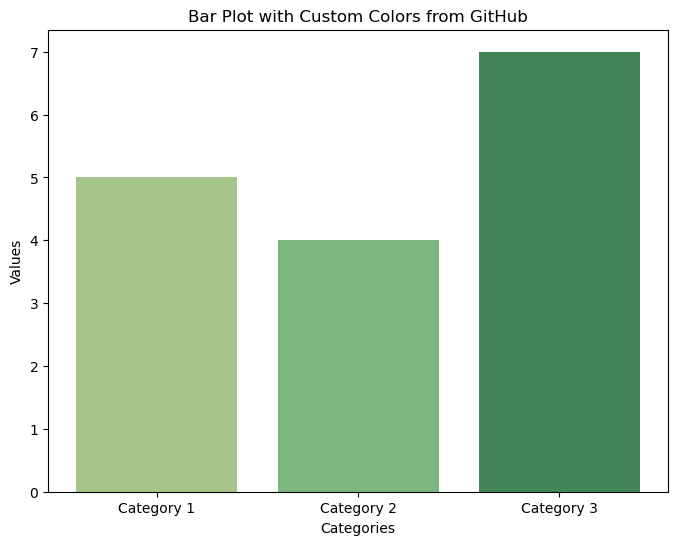

```python
#### When seaborn cannot be used, use this script for calling the same colors YlGn

### The get_bar_cols_greens function now includes a num_colors parameter which determines how many colors to return.
### Depending on the value of num_colors, the function returns a sublist of bar_cols_greens containing 1, 2, or 3 colors.

## Libraries
import matplotlib.pyplot as plt
import numpy as np
import requests

# Fetching the function from GitHub
url = "https://raw.githubusercontent.com/MiThomato/Graphs/main/bar_cols_greens.py"
response = requests.get(url)
exec(response.text)

# Generate sample data
categories = ['Category 1', 'Category 2', 'Category 3']
values = np.random.randint(1, 10, size=len(categories))
colors = get_bar_cols_greens(num_colors=3, alpha=0.9)  # Adjust alpha as desired

# Plotting
plt.figure(figsize=(8, 6))
bars = plt.bar(categories, values, color=colors)

# Add labels, title, and grid
plt.title('Bar Plot with Custom Colors from GitHub')
plt.xlabel('Categories')
plt.ylabel('Values')

# Show plot
plt.show()
```

Please note that this notebook serves only as an example. The purpose of this notebook is to demonstrate the thought process and is not exhaustive or complete.

Dr. Mia Thomaidou (2024)